# q_2

Christoffer Mondrup Kramer

2023-05-23

# Ex. 4 Q2

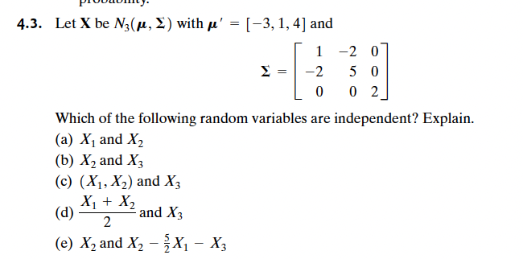

Let us first define the variables:

```r
mu <- c(-3, 1, 4)

x_1 <- c(1, -2, 0)
x_2 <- c(-2, 5, 0)
x_3 <- c(0, 0, 2)
sigma <- data.frame(
  x_1,
  x_2,
  x_3
)
sigma <- data.matrix(sigma)
```

## a

$X_1$ and $X_2$:

These are not independent since, their covariances are not zero:

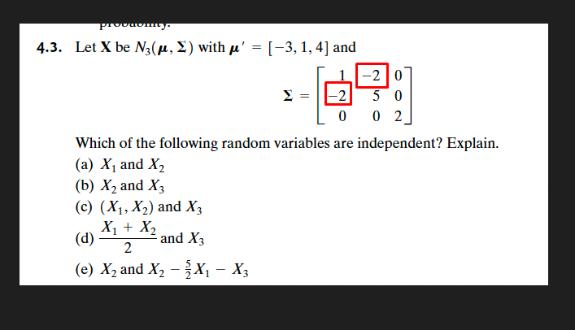

## b

$X_2$ and $X_3$:

These seem to be independent since their co-variance is 0, but it is not given

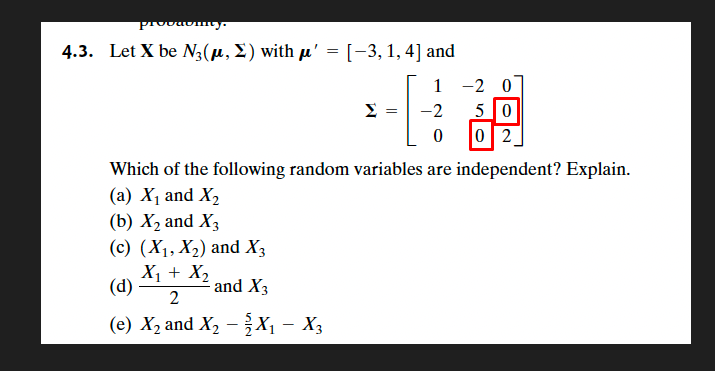

```r
# Get standard deviation matrix
std_dev <- sigma
std_dev[,] <- 0
diag(std_dev) <- sqrt(diag(sigma))
std_dev
```

```
##      x_1      x_2      x_3
## [1,]   1 0.000000 0.000000
## [2,]   0 2.236068 0.000000
## [3,]   0 0.000000 1.414214
```

```r
# calculate correlation matrix
cor_mat <- solve(std_dev) %*% sigma %*% solve(std_dev)
cor_mat
```

```
##           [,1]       [,2] [,3]
## x_1  1.0000000 -0.8944272    0
## x_2 -0.8944272  1.0000000    0
## x_3  0.0000000  0.0000000    1
```

```r
#The above was just for my own sake to make it easier just use R built in function
cov2cor(sigma)
```

```
##             x_1        x_2 x_3
## [1,]  1.0000000 -0.8944272   0
## [2,] -0.8944272  1.0000000   0
## [3,]  0.0000000  0.0000000   1
```

As we can see $X_2$ and $X_3$ has a correlation of zero, so I will conclude that they are most likely independent:

## c

$(X_1, X_2)$ and $X_3$. Yes since both $X_1$ and $X_2$ are independent from $X_3$.

## d

(($X_1$ + $X_2$) / 2 ) and $X_3$  
Yes again X_1 and X_2 might be dependent, but both variables are still independent from X_3

## e

$X_2$ and $X_2$ - $5/2X_1$ - $X_3$  
No Since x_1 and X_2 have a strong negative correlation and a shared co-variance they cannot be independent.